# Storm Data Analysis

### Author: Josh Jensen

Coursera / Johns Hopkins Reproducible Research Peer Assignment 2

## I. Synopsis

Using the ‘National Weather Service Storm Data’ data, I investigate which types of storm events are most harmful as well as the storm type that have the greatest economic consequences.

The data shows that tornadoes are the most deadly storm type with 5,636 recorded deaths since 1950, however this is in part due to their frequency of occurance. The most deadly storm type that the data shows is a tsunami, with a mean 1.65 deaths per storm (irrespective of severity).

As well, the data shows that tornadoes are by far the worst economically, causing over $51.7B in damages since 1950. Again this is due to frequency. So if we look at a per storm average, the data shows that hurricanes cause the most damages per storm ($36.8M per storm).

In conclusion, while other storm types are more damaging or fatal on average, the frequency of occurance makes tornadoes ‘suck’ for Americans the most.

## II. Data Processing

Load data from csv.bz2 using readr.

```r
library(readr)
library(dplyr)
library(ggplot2)
storm <- read_csv("repdata-data-StormData.csv.bz2")
```

## 1. Exploration

To explore the data, view data and create tables of variables of interest.

```r
view(storm)

colnames(storm)

table(storm$TIME_ZONE)
table(storm$COUNTY)
table(storm$STATE)

table(storm$EVTYPE)
```

### 2. Classify and Clean EVTYPE

The critical variable EVTYPE is widely not standardized due to multiple observers. Standardizing is critical before analyzing further.

The code below cleans the field to the dimensions specified in the ‘National Weather Service Storm Data Documentation’.

```r
# force to lower and create a data frame of every distinct evtype entry
# this is to opitmize the for loop runtime
storm$EVTYPE <- tolower(storm$EVTYPE)
evtype <- storm %>%
  select(EVTYPE) %>%
  group_by(EVTYPE) %>%
  count(events=EVTYPE) %>%
  arrange(desc(n))

# create a new variable that assigns a storm type base off of a grep match
stormtypes <- c("thunderstorm|tstm","tornado","hail", "tide","avalanche|slide","blizzard","flash flood","flood|fld","wind chill","fog","smoke","drought","dust devil","dust storm","heat|warm","freeze|frost","funnel cloud","heavy rain","snow","surf","wind","hurricane|typhoon","ice","lightning","rip current","seiche","sleet","tropical","tsunami","volcanic","waterspout","wildfire","cold","winter","dry","rain|precipitation")

evtype$stormtype <- NA

for(i in 1:length(stormtypes)){
  temp <- paste0("*",stormtypes[i],"*")

  evtype$temp_grep <- grepl(temp,evtype$events)
  evtype$stormtype <- ifelse(is.na(evtype$stormtype)&evtype$temp_grep==TRUE,
                             stormtypes[i],
                             evtype$stormtype)
}
evtype$temp_grep <- NULL
evtype$stormtype <- ifelse(is.na(evtype$stormtype),"other",evtype$stormtype)

evtype$stormtype <- gsub("\\|.*","",evtype$stormtype)

# join the created variable back to the master set
storm <- left_join(storm, evtype , by = c("EVTYPE"="events"))
```

## III. Results

### 1. Across the United States, which types of events (as indicated in the EVTYPE variable) are most harmful with respect to population health?

To answer this, let’s use FATALITIES as our primary measure and look at aggregates by storm type.

Absolute fatalities will show us the storm types most historically harmful; this is slanted towards the more frequent type of storms. Per storm fatalities will show how fatal any one given storm of that type is expected to be (regardless of severity).

```r
storm_deaths <- storm %>%
  group_by(stormtype) %>%
  summarise(deaths = sum(FATALITIES), deathsperstorm = mean(FATALITIES))


# top 10 storms by absolute fatalities
storm_deaths_abs <- storm_deaths %>% filter(deaths>0) %>% arrange(desc(deaths)) %>% top_n(10,deaths)
storm_deaths_abs
```

```
## Source: local data frame [10 x 3]
##
##       stormtype deaths deathsperstorm
## 1       tornado   5636    0.092851612
## 2          heat   3172    1.072346180
## 3   flash flood   1035    0.018593371
## 4     lightning    817    0.051840102
## 5  thunderstorm    754    0.002238658
## 6          wind    748    0.016177870
## 7   rip current    572    0.739018088
## 8         flood    518    0.017020997
## 9     avalanche    268    0.257940327
## 10   wind chill    220    0.138888889
```

```r
# top 10 storms by per storm fatalities
storm_deaths_perstorm <- storm_deaths %>% filter(deaths>0) %>% arrange(desc(deathsperstorm)) %>% top_n(10,deathsperstorm)
storm_deaths_perstorm
```

```
## Source: local data frame [10 x 3]
##
##      stormtype deaths deathsperstorm
## 1      tsunami     33     1.65000000
## 2         heat   3172     1.07234618
## 3  rip current    572     0.73901809
## 4    hurricane    133     0.44630872
## 5    avalanche    268     0.25794033
## 6         cold    214     0.24071991
## 7         surf    187     0.14017991
## 8   wind chill    220     0.13888889
## 9        other     56     0.10428305
## 10     tornado   5636     0.09285161
```

Now lets view these together in a plot:

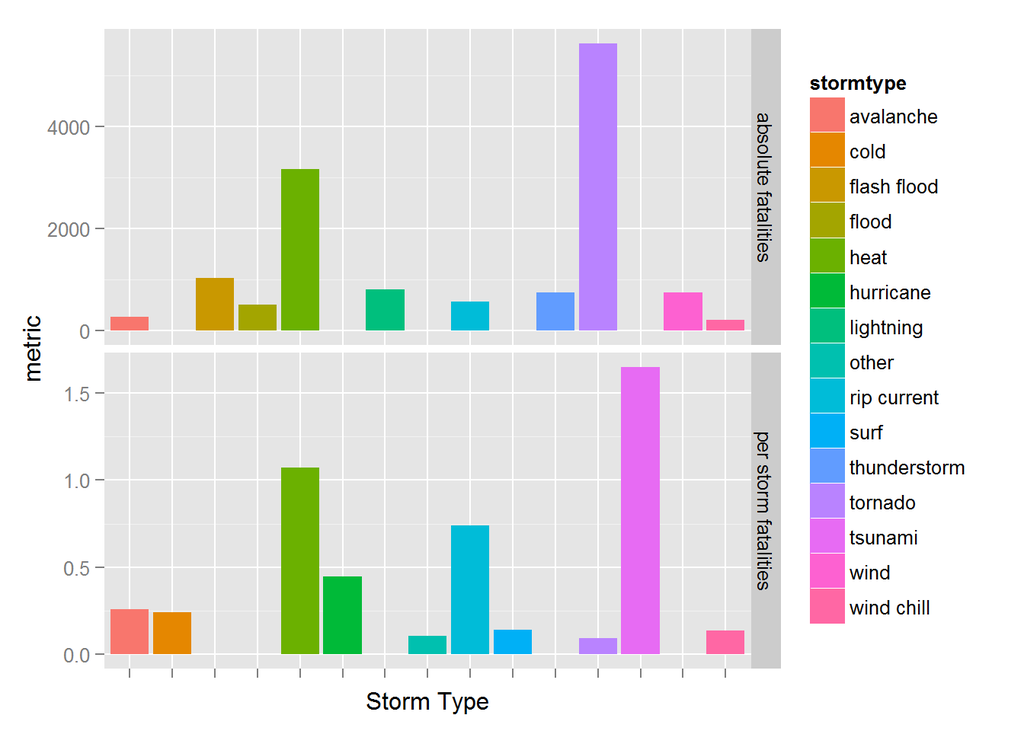

```r
storm_deaths_abs$type <- "absolute fatalities"
storm_deaths_perstorm$type <- "per storm fatalities"
deathsplot <- bind_rows(storm_deaths_abs,storm_deaths_perstorm)
deathsplot$metric <- ifelse(deathsplot$type=="absolute fatalities",deathsplot$deaths,deathsplot$deathsperstorm)

v1 <- ggplot(data=deathsplot, aes(x=stormtype, y=metric, fill=stormtype)) +
  geom_bar(stat="identity",aes(order = desc(metric))) +
  facet_grid(type ~ ., scales = "free") +
  xlab("Storm Type") +
  theme(axis.text.x=element_blank())
v1
```

### 2. Across the United States, which types of events have the greatest economic consequences?

We will evaluate this by PROPDMG. However, this variable needs to be weighted by PROPDMGEXP and cleaned first.

```r
# storm$PROPDMG needs to be weighted by storm$PROPDMGEXP
storm$PROPDMGEXP <- ifelse(storm$PROPDMGEXP=="m","M",
                           ifelse(storm$PROPDMGEXP=="K","K",
                                  ifelse(storm$PROPDMGEXP=="M","M","0")))

storm$propdmg_clean <- ifelse(storm$PROPDMGEXP=="M",storm$PROPDMG*1000000,
                              ifelse(storm$PROPDMGEXP=="K",storm$PROPDMG*1000,
                                     ifelse(storm$PROPDMGEXP=="0",storm$PROPDMG,NA)))
```

Now that PROPDMG is clean, we will proceed as before. This time we will use propdmg_clean as our primary measure and look at aggregates by storm type.

Again absolute fatalities will show us the storm types most historically harmful and is slanted towards the more frequent type of storms. As well, per storm fatalities will show how fatal any one given storm of that type is expected to be (regardless of severity).

```r
storm_damages <- storm %>%
  group_by(stormtype) %>%
  summarise(damages = sum(propdmg_clean), damagesperstorm = mean(propdmg_clean))


# top 10 storms by absolute damages
storm_damages_abs <- storm_damages %>% filter(damages>0) %>% arrange(desc(damages)) %>% top_n(10,damages)
storm_damages_abs
```

```
## Source: local data frame [10 x 3]
##
##       stormtype     damages damagesperstorm
## 1       tornado 51693098034       851630.14
## 2         flood 23181199523       761712.60
## 3   flash flood 15906357188       285751.50
## 4          hail 14174564050        48998.95
## 5     hurricane 10956410084     36766476.79
## 6  thunderstorm  9776120481        29025.71
## 7          wind  6664192880       144134.29
## 8           ice  6533200715      2078651.20
## 9      wildfire  3825614001      1381586.85
## 10          fog  1532061002       458289.26
```

```r
# top 10 storms by per storm damages
storm_damages_perstorm <- storm_damages %>% filter(damages>0) %>% arrange(desc(damagesperstorm)) %>% top_n(10,damagesperstorm)
storm_damages_perstorm
```

```
## Source: local data frame [10 x 3]
##
##    stormtype     damages damagesperstorm
## 1  hurricane 10956410084      36766476.8
## 2    tsunami   144062000       7203100.0
## 3        ice  6533200715       2078651.2
## 4       tide   650946154       1418183.3
## 5   wildfire  3825614001       1381586.9
## 6      other   629796100       1172804.7
## 7    tornado 51693098034        851630.1
## 8      flood 23181199523        761712.6
## 9       surf   865511043        648808.9
## 10       fog  1532061002        458289.3
```

Now lets view these together in a plot:

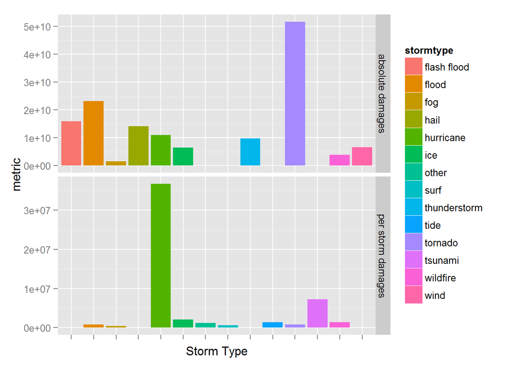

```r
storm_damages_abs$type <- "absolute damages"
storm_damages_perstorm$type <- "per storm damages"
damageplot <- bind_rows(storm_damages_abs,storm_damages_perstorm)
damageplot$metric <- ifelse(damageplot$type=="absolute damages",damageplot$damages,damageplot$damagesperstorm)

v2 <- ggplot(data=damageplot, aes(x=stormtype, y=metric, fill=stormtype)) +
  geom_bar(stat="identity",aes(order = desc(metric))) +
  facet_grid(type ~ ., scales = "free") +
  xlab("Storm Type") +
  theme(axis.text.x=element_blank())
v2
```